# Gaps in O'Reilly's Python repertoire

Tanya Schlusser 11 December 2014

Slides prepared using iPython Notebook. [(Awesome quick tutorial](http://www.slideviper.oquanta.info/tutorial/slideshow_tutorial_slides.html#/10)... [and how to 'Markdown')](http://daringfireball.net/projects/markdown/syntax)

Following along? Clone this: https://github.com/tanyaschlusser/ipython_talk__OReilly_python_books

## Motivation

[figure not shown]

## But

[figure not shown]

## So we

[figure not shown]

## What to do?

## Option 1

[figure not shown]

## Option 2

[figure not shown]

## Option Oh Heck Yeah

[figure not shown]

## And the reaction?

## Not naming names... B---- R--

[figure not shown]

## Well I say

[figure not shown]

## Well, it would be a haul ...

...wouldn't be able to get a drink for the next 18 - 36 months...

## But what to write?

There are over 120 Python publications by O'Reilly alone

[figure not shown]

## Approach it systematically:

1. See what's out there now
2. Think about what we can contribute
3. Lots of writing

## So, what's out there now?

Of course we're going to use Python to find out. And of course the universe is only the size of O'Reilly

```python
# See what's out there now. Pull the:
#  -- media type (book | video)
#  -- title
#  -- publication date
import requests
from bs4 import BeautifulSoup

books_uri = "http://shop.oreilly.com/category/browse-subjects/programming/python.do?sortby=publicationDate&page=%d"
```

```python
# Loop over all of the pages
results = []
description_results = {}
for page in range(1,5):
    result = requests.get(books_uri % page)
    soup = BeautifulSoup(result.text)
    books = soup.find_all("td", "thumbtext")
    for b in books:
        yr = b.find("span", "directorydate").string.strip().split()
        while not yr[-1].isdigit():
            yr.pop()
        yr = int(yr[-1])
        title = b.find("div", "thumbheader").text.strip()
        url = b.find("div", "thumbheader").find("a")["href"]
        hasvideo = "Video" in b.text
        results.append(dict(year=yr, title=title, hasvideo=hasvideo))
```

```python
# Want to
#  -- plot year over year number of books
#      ++ stacked plot with video + print
#  -- Get all the different words in the titles
#     ++ count them
#     ++ and order by frequency
#
# Use the Matplotlib magic command. Magic commands start with '%'.
# This sets up to plot inline. It doesn't import anything...
# Or use %pylab inline -- this apparently imports a lot of things into
# the global namespace
#
%matplotlib inline
```

```python
# For year over year I need pandas.DataFrame.groupby
# For stacked plot I need matplotlib.pyplot
# Plain dictionary for the word counts
#
import matplotlib.pyplot as plt
import pandas as pd
```

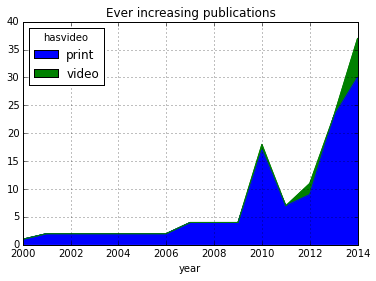

```python
# Year over year -- number of publications by 'video' and 'print'.
#
df = pd.DataFrame(results)
byyear = pd.crosstab(df["year"],df["hasvideo"])
byyear.rename(columns={True:'video', False:'print'}, inplace=True)
byyear.plot(kind="area", xlim=(2000,2014), title="Ever increasing publications")
```

## Um

That actually wasn't very satisfying...

```python
# Out of curiosity, what happened in 2010?
df[df["year"]==2010]
```

|  | hasvideo | title | year |
| --- | --- | --- | --- |
| 77 | False | Python 2.6 Text Processing Beginner's Guide | 2010 |
| 78 | False | Programming Python, 4th Edition | 2010 |
| 79 | False | Python Geospatial Development | 2010 |
| 80 | False | wxPython 2.8 Application Development Cookbook | 2010 |
| 81 | False | Python 2.6 Graphics Cookbook | 2010 |
| 82 | False | Head First Python | 2010 |
| 83 | False | Real World Instrumentation with Python | 2010 |
| 84 | False | Python Text Processing with NLTK 2.0 Cookbook | 2010 |
| 85 | False | MySQL for Python | 2010 |
| 86 | False | Python Multimedia | 2010 |
| 87 | True | Practical Python Programming: Callbacks | 2010 |
| 88 | False | Python 3 Object Oriented Programming | 2010 |
| 89 | False | Spring Python 1.1 | 2010 |
| 90 | False | Blender 2.49 Scripting | 2010 |
| 91 | False | Professional IronPython | 2010 |
| 92 | False | Grok 1.0 Web Development | 2010 |
| 93 | False | Beginning Python | 2010 |
| 94 | False | Python Testing | 2010 |

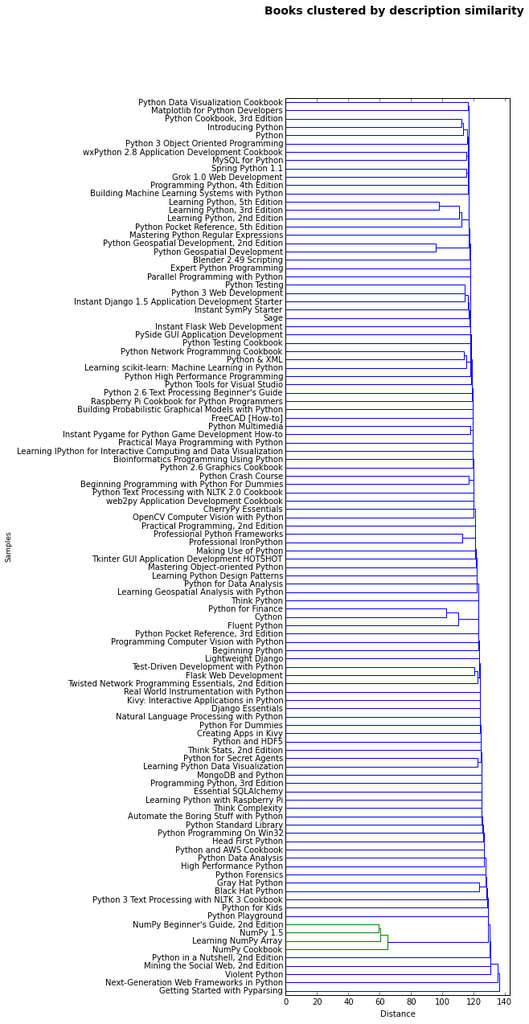

```python
plt.figure(figsize=(5,20))
data_link = linkage(percent_overlap, method='single', metric='euclidean')

den = dendrogram(data_link,labels=sorted_titles, orientation="left")

plt.ylabel('Samples', fontsize=9)
plt.xlabel('Distance')
plt.suptitle('Books clustered by description similarity', fontweight='bold', fontsize=14);
```

```python
from IPython.display import HTML

container = """
    <a href='http://bl.ocks.org/mbostock/4063570'>Layout attribution: Michael Bostock</a>
    <div id='display_container'></div>"""

with open("data/d3-stacked-Tree.js") as infile:
    display_js = infile.read()

with open("data/human_hclust.json") as infile:
    the_json = infile.read()

HTML(container + display_js % the_json )
```

[Layout attribution: Michael Bostock](http://bl.ocks.org/mbostock/4063570)

## Quick interpretation

It makes sense that topics have little overlap. Otherwise why write a different book? Do we have anything to contribute?

- Pure programming
  - Unless we write our own library, I think this space is full
  - Plus, any book should be better than Udacity / existing blogs, or why do it?
- Games / Web
  - Lots of expertise here, right? (Not me, but what percent of ChiPy does this?)
- Scientific / Hobby
  - The other half of ChiPy? The finance guys? (What percent?)
  - We could actually contact the pyMCMC guy [Thomas Wiecki](http://twiecki.github.io/bayesian_risk_perf_boston_data_fest14.slides.html#/) and offer to help him out

## Thank you -- what next?

- Contact me if you want do do something
- Ideas welcome
- This may or may not happen
  - depends on interest
  - and whether interest can be sustained

## There was support for a 'personality piece'

- About local Chicago successes (Thanks Don Sheu!)
- Idea:
  - Python in production seems newer, and we have a handful of local companies who have gone this route
  - A [recent Berkely paper](http://db.cs.berkeley.edu/papers/vast12-interview.pdf) summarizes today's enterprise analytics pipeline:
    - Three types of people:
      - **App users** (e.g. Business Objects, Qlikview)
      - **Scripters** (e.g. SAS)
      - **Hackers** (whole workflow: SQL (100%) + Python(63%) + various)
    - Some issues:
      - Visualization at the data exploration stage
      - Managing the workflow
      - Isolated inaccessible 3rd party data
  - We've (as a community) figured out how to do this -- could this be our book?
    - How different successful local firms use Python in production

## Postscript: IPython evangelism

Making this deck in IPython was life-changing -- Python talks *belong* in IPython.

How to:

1. **.github.io repo:** [(instructions)](https://pages.github.com/)
2. **Make the notebook**

   ```
    pip install ipython
    ipython notebook  # Make something.
   ```

   Remember to identify the slides:

[figure not shown]

3. **Convert to html slideshow**

   ```
    export PREFIX=http://cdn.jsdelivr.net/reveal.js/2.6.2
    ipython nbconvert <my_notebook>.ipynb \
        --to slides \
        --reveal-prefix ${PREFIX}
   ```

4. **Add the new slides to the .github.io repo**. The slides are served statically
5. Wait about 10 minutes and the slides are there

Also:

- Can include javascript -- even libraries [(example with D3)](http://nbviewer.ipython.org/github/dboyliao/cookbook-code/blob/master/notebooks/chapter06_viz/04_d3.ipynb)
- As customizable as your imagination, [using reveal.js for the slides](http://lab.hakim.se/reveal-js/#/)